# KnitR-Carpentry-Lesson

Julieanne Montaquila

2026-10-28

### Challenge 1

Create a new R Markdown document. Delete all of the R code chunks and write a bit of Markdown (some sections, some italicized text, and an itemized list).

Convert the document to a webpage. (html)

[Carpentries Home Page](https://carpentries.org/)

## Notation

Subscripts: F<sub>2</sub>

Superscripts: F<sup>2</sup>

You can review Markdown syntax by navigating to the “Markdown Quick Reference” under the “Help” field in the toolbar at the top of RStudio.

Chunks are for code.

### Challenge 2:

Add a code chunk that:

1. Loads the ggplot2 package
2. Reads the gapminder data, and,
3. Creates a plot

## Chunk Options

### Challenge 3

Use chunk options to control the size of a figure and to hide the code.

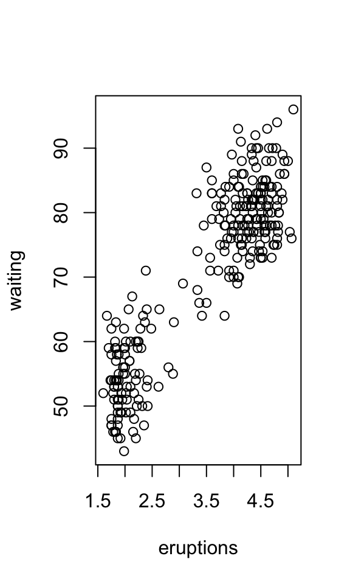

### Tip: Creating PDF documents

Creating .pdf documents may require installation of some extra software. The R package tinytex provides some tools to help make this process easier for R users. With tinytex installed, run tinytex::install_tinytex() to install the required software (you’ll only need to do this once) and then when you knit to pdf tinytex will automatically detect and install any additional LaTeX packages that are needed to produce the pdf document. Visit the tinytex website for more information.